# Global Warming

Manu

9/2/2020

library(forecast) library(fpp2) library(tseries) library(seasonal) library(TSA) library(descomponer) library(knitr) library(ggplot2) library(tidyr) library(ggthemes) library(dplyr) library(nortest)

The data contains the Global-Mean temperature change by month, available at NASA’s website. It gathers the temperature variation from 1880/01 to December 2019/12, however, only data from the last 50 years will be analyzed.

# 1. Tidying the data.

The first row of the csv was the title of the database so it needs to be skipped.

- The structure of the data frame is not appropriate for a time series, R will consider it as a time series of 140 observations and 19 variables.
- The proper structure for a monthly study is sequential, that is, only one column containing all observations arranged by date. Therefore, values from Jan to Dec, need to be switched into one column. It sounds messy but **tidyr** is quite useful facing those kinds of issues.

```r
global_w <- read.csv("GLB.Ts+dSST.csv",header = T,skip = 1)
dim(global_w)
```

```
## [1] 140  19
```

```r
head(global_w)
```

```
##   Year   Jan   Feb   Mar   Apr   May   Jun   Jul   Aug   Sep   Oct   Nov
## 1 1880 -0.17 -0.23 -0.08 -0.15 -0.09 -0.20 -0.17 -0.09 -0.14 -0.22 -0.21
## 2 1881 -0.18 -0.13  0.04  0.06  0.07 -0.17  0.01 -0.02 -0.14 -0.20 -0.17
## 3 1882  0.18  0.15  0.06 -0.15 -0.14 -0.22 -0.15 -0.06 -0.14 -0.23 -0.15
## 4 1883 -0.28 -0.36 -0.12 -0.18 -0.17 -0.06 -0.07 -0.13 -0.21 -0.11 -0.23
## 5 1884 -0.12 -0.08 -0.36 -0.39 -0.34 -0.34 -0.32 -0.27 -0.27 -0.24 -0.32
## 6 1885 -0.57 -0.32 -0.25 -0.41 -0.44 -0.42 -0.32 -0.29 -0.27 -0.22 -0.22
##     Dec   J.D  D.N  DJF   MAM   JJA   SON
## 1 -0.16 -0.16  ***  *** -0.11 -0.15 -0.19
## 2 -0.06 -0.07 -.08 -.16  0.06 -0.06 -0.17
## 3 -0.35 -0.10 -.08  .09 -0.08 -0.14 -0.17
## 4 -0.10 -0.17 -.19 -.33 -0.16 -0.09 -0.18
## 5 -0.30 -0.28 -.26 -.10 -0.36 -0.31 -0.28
## 6 -0.08 -0.32 -.34 -.40 -0.37 -0.35 -0.24
```

To switch the columns simply use the t() function which returns the **transpose** of a matrix or data frame.

```r
global_w <- global_w %>%
  filter(Year>=1970) %>%
  select( -c(J.D:SON))

global_w <- as.data.frame(t(global_w))

head(global_w,2)
```

```
##           V1      V2      V3      V4     V5     V6      V7      V8      V9
## Year 1970.00 1971.00 1972.00 1973.00 1974.0 1975.0 1976.00 1977.00 1978.00
## Jan     0.08   -0.03   -0.22    0.29   -0.1    0.1   -0.03    0.18    0.06
##          V10    V11     V12     V13     V14     V15     V16     V17
## Year 1979.00 1980.0 1981.00 1982.00 1983.00 1984.00 1985.00 1986.00
## Jan     0.08    0.3    0.52    0.04    0.53    0.31    0.22    0.27
##          V18     V19     V20     V21     V22     V23     V24     V25
## Year 1987.00 1988.00 1989.00 1990.00 1991.00 1992.00 1993.00 1994.00
## Jan     0.32    0.56    0.11    0.41    0.42    0.47    0.34    0.26
##          V26     V27     V28     V29     V30     V31     V32     V33
## Year 1995.00 1996.00 1997.00 1998.00 1999.00 2000.00 2001.00 2002.00
## Jan     0.52    0.23    0.29    0.58    0.48    0.25    0.46    0.77
##          V34     V35     V36     V37     V38    V39     V40     V41
## Year 2003.00 2004.00 2005.00 2006.00 2007.00 2008.0 2009.00 2010.00
## Jan     0.75    0.58    0.74    0.56    1.01    0.3    0.65    0.75
##          V42     V43     V44     V45     V46     V47     V48     V49
## Year 2011.00 2012.00 2013.00 2014.00 2015.00 2016.00 2017.00 2018.00
## Jan     0.52    0.49    0.71    0.76    0.86    1.17    1.03    0.82
##          V50
## Year 2019.00
## Jan     0.93
```

Here, the new columns are named by the years and “Year” row is omitted.

```r
colnames(global_w) = as.character(global_w[1,])
names(global_w)
```

```
##  [1] "1970" "1971" "1972" "1973" "1974" "1975" "1976" "1977" "1978" "1979"
## [11] "1980" "1981" "1982" "1983" "1984" "1985" "1986" "1987" "1988" "1989"
## [21] "1990" "1991" "1992" "1993" "1994" "1995" "1996" "1997" "1998" "1999"
## [31] "2000" "2001" "2002" "2003" "2004" "2005" "2006" "2007" "2008" "2009"
## [41] "2010" "2011" "2012" "2013" "2014" "2015" "2016" "2017" "2018" "2019"
```

```r
global_w <- global_w[-1,]
```

Tidyr’s gather() function allow to *“nest”* the observation in one column.

```r
global_w <- gather(global_w, Year, Value)
global_w %>% head()
```

```
##   Year Value
## 1 1970  0.08
## 2 1970  0.22
## 3 1970  0.06
## 4 1970  0.05
## 5 1970 -0.04
## 6 1970 -0.03
```

```r
global_df <- global_w

library(lubridate)
```

Once the data is cleaned and sorted, just transform it into a time series object.

```r
global_w <- ts(global_w[,"Value"], start = c(1970,1),frequency = 12)
```

# 2. Series Decomposition.

As the variance remains constant the decomposition method will be additive:

$\hat{R}_t = y_t - \hat{T}_t - \hat{S}_t$

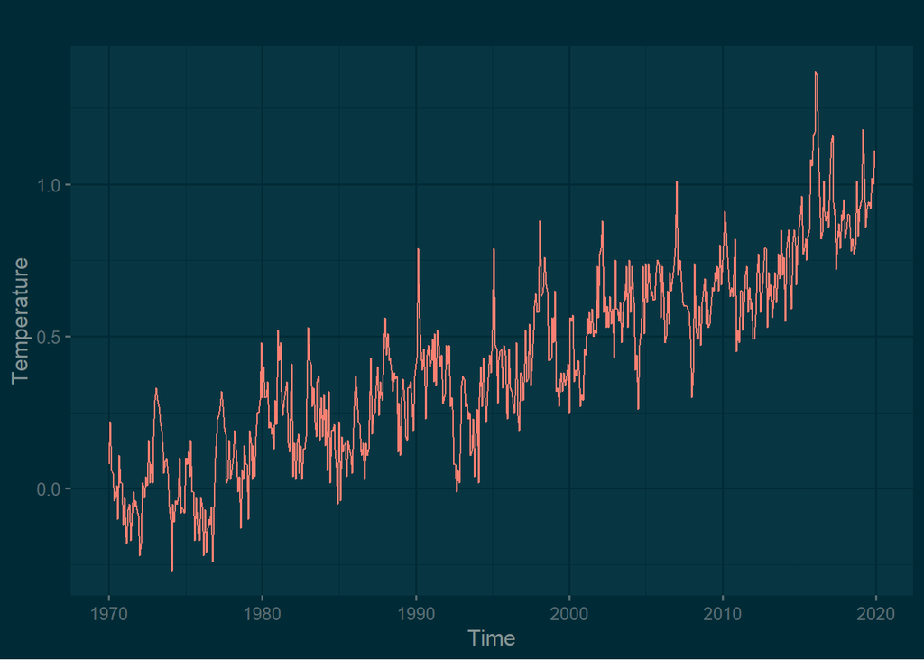

```r
autoplot(global_w) + geom_line(color="salmon") + theme_solarized_2(light = F) + labs(y="Temperature")
```

First things first, in order to know if forecast models will work efficiently, it is essential to observe the variance, trend and seasonality of time series.

1. There is a positive trend.
2. The variance seems to be constant.
3. There is way too much seasonality, which is logical because of the climate seasons.
4. Conclusion: It is not stationary.

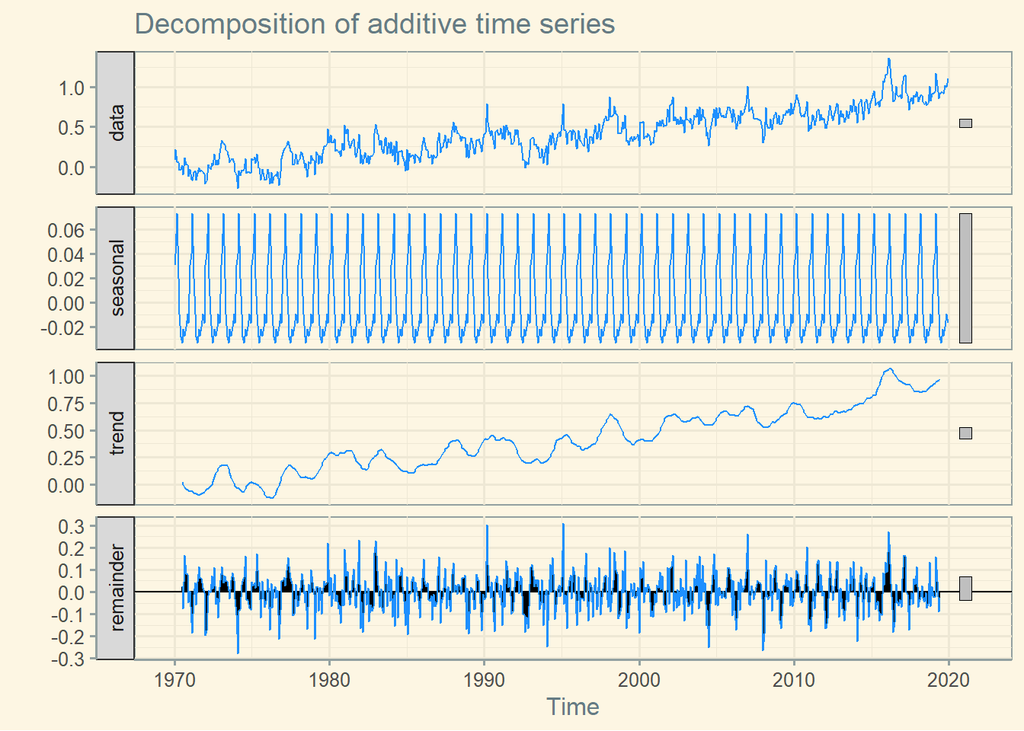

```r
global_w_desc <- decompose(global_w, type="additive")
autoplot(global_w_desc) + geom_line(color="dodgerblue") +
  theme_solarized()
```

Next, the residuals of the decomposition are checked. They are supposed to be “White Noise”, that is, they must be normal.

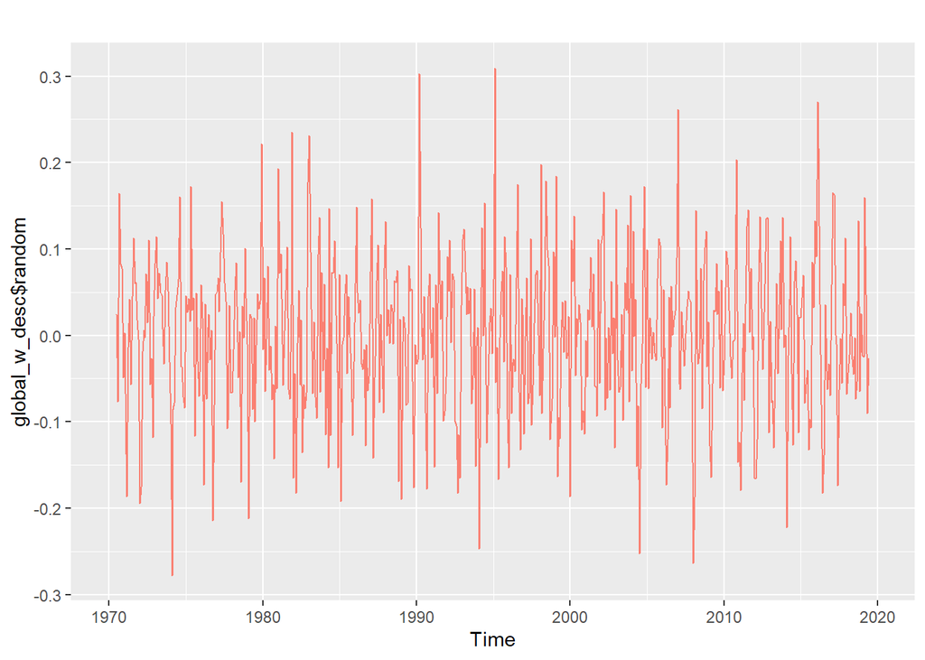

```r
autoplot(global_w_desc$random) + geom_line(color="salmon")
```

```r
shapiro.test(global_w_desc$random )
```

```
##
##  Shapiro-Wilk normality test
##
## data:  global_w_desc$random
## W = 0.99593, p-value = 0.1324
```

```r
lillie.test(global_w_desc$random)
```

```
##
##  Lilliefors (Kolmogorov-Smirnov) normality test
##
## data:  global_w_desc$random
## D = 0.032788, p-value = 0.13
```

Plotting the seasonality by year.

- It seems that in the latest years the temperature rise is more pronounced in winter.

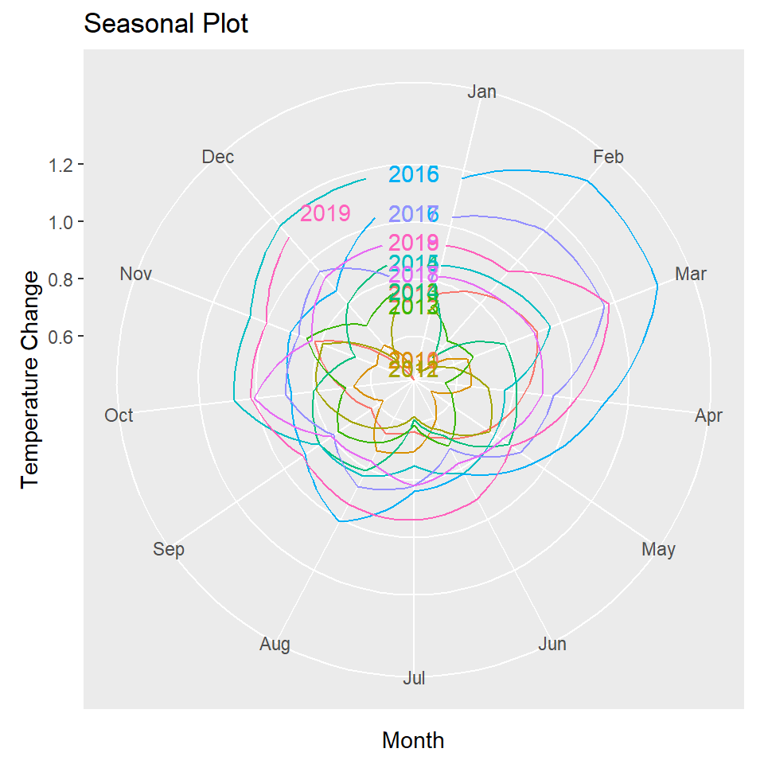

```r
ggseasonplot(ts(global_w[481:600], start = c(2010,1), frequency = 12), polar=T, year.labels = T, year.labels.left = T) +
  labs(x="Month", y="Temperature Change", title="Seasonal Plot")
```

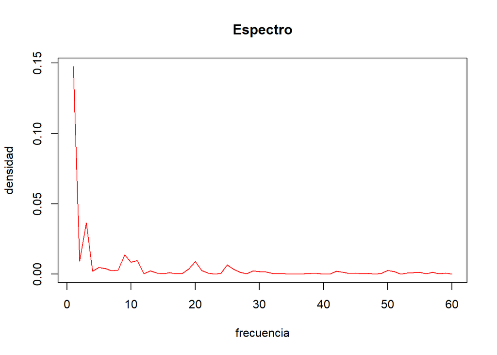

```r
gperiodograma(ts(global_w[481:600], start = c(2010,1), frequency = 12))
```

# 3. To Stationary.

Rid trend and Seasonality.

*Trend:* Just by computing the differences between observations: $x'_t = x_t - x_{t-1}$. *Seasonality:* Differentiating by the last season (m): $x'_t = x_t - x_{t-m}$.

- A stationary time series was achieved, so **SARIMA, Holt-Winters and Neural Networks** can be used.

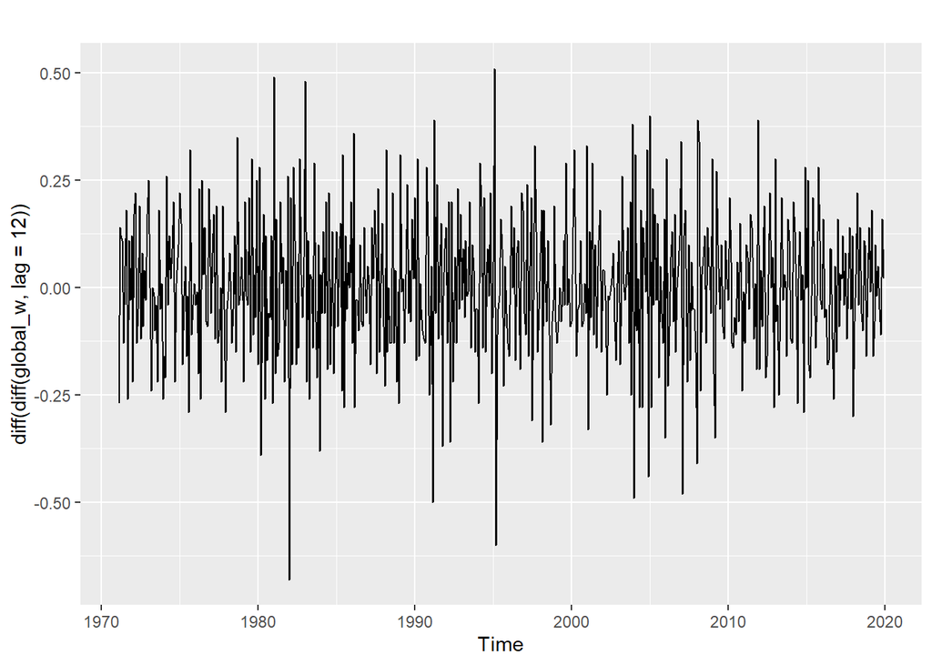

```r
autoplot(diff(diff(global_w, lag = 12)))
```

## 3.1 Dickey-Fuller

The time series is Stationary under Dickey-Fuller Test.

Dickey-Fuller test (ADF) is a unit root test for a sample of a time series. The Increased Dickey-Fuller (ADF) statistic, specific to the test, is a negative number. The more negative it is, the stronger the rejection of the null hypothesis that there is a unitary root for a certain level of trust.

```r
adf.test(diff(diff(global_w,3)))
```

```
##
##  Augmented Dickey-Fuller Test
##
## data:  diff(diff(global_w, 3))
## Dickey-Fuller = -15.131, Lag order = 8, p-value = 0.01
## alternative hypothesis: stationary
```

# 4. Holt-Winters.

Split in train and test.

```r
gw_tr <- window(x = global_w, end = c(2017, 12))
gw_tst <- window(x = global_w, start = c(2018, 1))
```

H-W additive model takes into account the level, the trend and the season to compute fit the values, thus, it requires 3 smoothing parameters: $\alpha (level), \beta (Trend), \gamma(Season)$.

So the equations are the following:

- $L_t = \alpha(x_t - S_{t-s}) + (1-\alpha)(L_{t-1} + b_{t-1})$
- $b_{t} = \beta^*(L_t - L_{t-1}) + (1-\beta)b_{t-1}$
- $S_t = \gamma(xt - L_{t-1}- b_{t-1}) + (1-\gamma)St_{-s}$

Lt = *(alpha) X (today value adjusted by the season) + (1-alpha) X (t-1 estimated value without season)* bt = *beta X (estimated slope) + (1-beta) X (Today slope/trend)* st = *gamma X (Today season) + (1-gamma) X (s-1 Season ~ last season)*

Fitting the values with $\hat{x_t} = L_t + bt +S_{t+1−s} + z_t$; being Z the residual error.

So in the end the concept is similar to a weighted average… What is more important to compute $\hat{x_t}$?

- Today value or estimated value? As shown if the formula if $\alpha$ is 0.99 is giving importance to today value vs. $1-0.99=.001$ * Estimated value, that would not be important and the same with the trend and season. That’s why $\alpha (level), \beta (Trend), \gamma(Season)$ are called smoothing parameters.
- Today trend or estimated trend?
- This season or last season?

Notice that it also exists H-W multiplicative method, used when the variance is not constant through time. $\hat{x_t} = (L_t + bt)*S_{t+1−s} + z_t$

Note that $\alpha, \beta, \gamma$ and initial $Lt_0,bt_0,St_0$ are computed by minimizing the $\sum_{i=1}^n (x_{ti} - \hat{x}_{ti})^2$.

When fitting the model:

- $\alpha$ = 0.22 -> More importance to estimated value without seasonality.
- $\beta$ ~= 0 -> All the importance to last trend/slope.
- $\gamma$ = 0.14 -> More importance to last season.

```r
hw <- hw(gw_tr, h=24, seasonal = "additive", level = c(80,95))
hw$model
```

```
## Holt-Winters' additive method
##
## Call:
##  hw(y = gw_tr, h = 24, seasonal = "additive", level = c(80, 95))
##
##   Smoothing parameters:
##     alpha = 0.2193
##     beta  = 1e-04
##     gamma = 0.1424
##
##   Initial states:
##     l = -0.1705
##     b = 4e-04
##     s = 0.0247 0.006 0.138 -0.1719 0.0851 -0.1628
##            0.0049 -0.2521 0.0553 0.1121 0.0492 0.1114
##
##   sigma:  0.1244
##
##      AIC     AICc      BIC
## 1277.992 1279.089 1352.046
```

Testing the solution:

```r
round(hw$fitted[1],2)
```

```
## [1] -0.06
```

```r
# If fitted xt = L0+B0+S0 then;
round(-0.1705 + 4e-04 + 0.1121, 2)
```

```
## [1] -0.06
```

For xt2, note that $x_t$ is $x_{t-1}$ (0.08), this is the “lag”.

```r
hw$x[1] # real observation
```

```
## [1] 0.08
```

$L_t = 0.2193*(0.08 - 0.1121 ) + 0.7807*(-0.1705 + 0.0004); L_t = -0.13$ $b_{t} = 0.0001*(-0.13 -0.1705) + 0.9999*0.0004; b_t = 0.00037$ $S_t = 0.1424*(0.08 - (-0.004) - 0.1705) + 0.8676*0.1121; S_t = 0.13$

Fitted values can be mathematically calculated.

```r
lt = 0.2193*(0.08 - 0.1121) + 0.7807*(-0.1705 + 0.0004)
bt = 0.0001*(lt-0.1705) + 0.9999*0.0004
st = 0.1424*(0.08 - 0.0004 - -.1705) +  0.8676* 0.1121 # To compute next year (xt+12)

# Used St+1-s -> (Initial S obtained from the fit next to -0.1121).
round(lt + bt + 0.0492,3)
```

```
## [1] -0.09
```

```r
round(hw$fitted[2],3)
```

```
## [1] -0.09
```

Accuracy and plots:

- It’s interesting that it just has a 0.09 of RMSE in test while in train has 0.12. That is, the forecast is more accurate than the actual fitting of the series.
- It seems that H-W predicts very well.

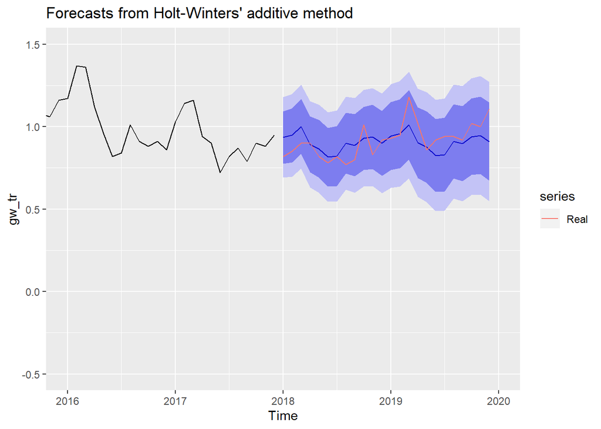

```r
autoplot(hw) + autolayer(gw_tst, series = "Real")  + coord_cartesian(ylim=c(-0.5,1.5), xlim = c(2016,2020))
```

```r
accuracy(hw, gw_tst)
```

```
##                       ME       RMSE        MAE       MPE     MAPE     MASE
## Training set 0.005341146 0.12267711 0.09706106       Inf      Inf 0.631255
## Test set     0.009576799 0.09005409 0.07266229 0.1681028 7.815456 0.472573
##                   ACF1 Theil's U
## Training set 0.2596139        NA
## Test set     0.3114419   0.89498
```

The residuals are also white noise. It obvious that is a good mode.

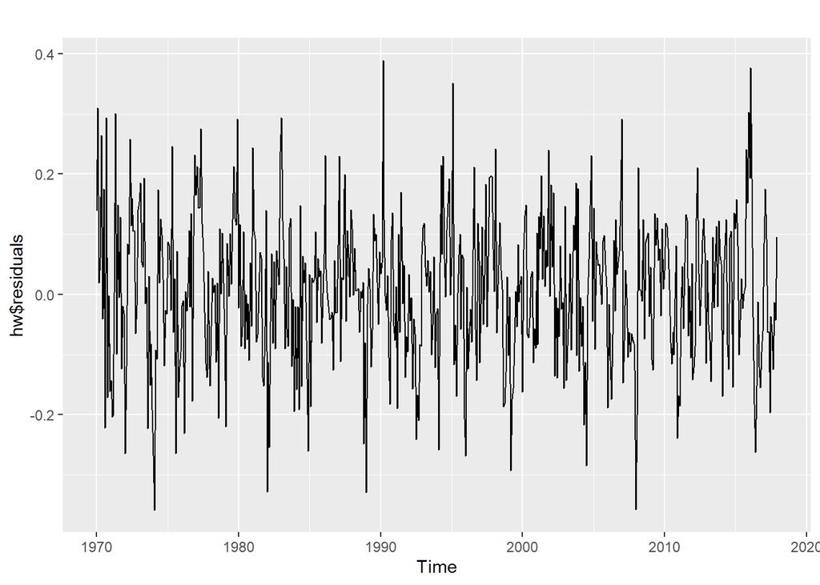

```r
autoplot(hw$residuals)
```

# 5. ARIMA.

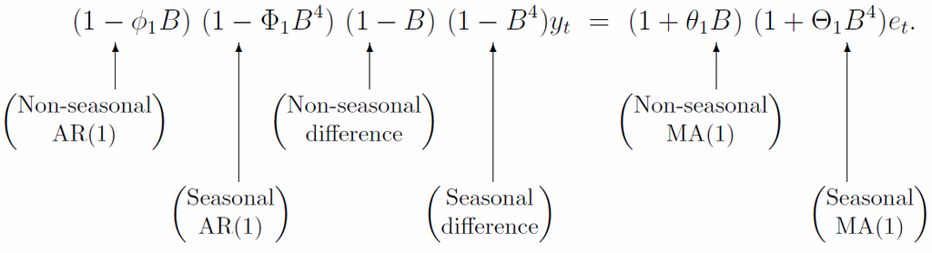

```r
include_graphics(path = "images/arima.png")
```

Unfortunately auto.arima() function is not working or it takes way too much time so the best ARIMA has to be identify manually. The data may be too complex for auto.arima() to estimate the model with the lowest AIC.

We show the Auto-correlations $xt-x_{t-1}$ and the Partial auto-correlations $xt-x_{t-k}$ which removes the lags effects.

$r_{k} = \frac{\sum\limits_{t=k+1}^T (y_{t}-\bar{y})(y_{t-k}-\bar{y})}{\sum\limits_{t=1}^T (y_{t}-\bar{y})^2}$

Notice the similarities with the normal correlation formula. Covariance/variance.

- As a pike breaks in the ACF, probably there is a MA (1 or 2) for the not seasonal part. In the PACF the auto correlations decrease.
- There are 2 significant pikes at lag 12 and 13 in the ACF indicating a MA(2) in the seasonal part. The PACF decrease again.
- 2 diff were made, one for the non-seasonal and another for the seasonal.

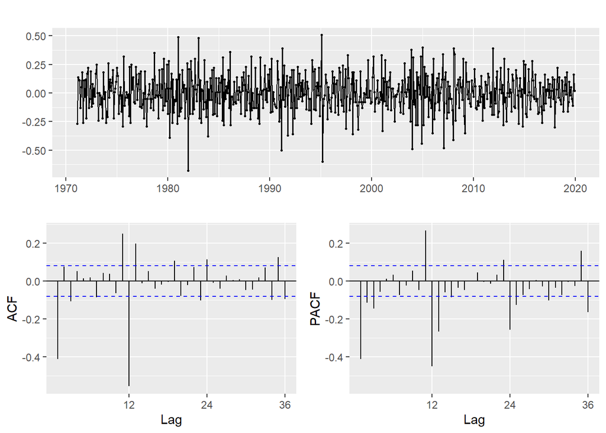

```r
ggtsdisplay(diff(diff(global_w,12)))
```

The parameters are estimated by Maximum likelihood estimation. (Coeff. that maximize the probability of the data). An ARIMA(0,1,1)(0,1,2)[12] is proposed.

Where $\beta$ is the lag, for example $\beta^{12}=x_{-12}$

```r
ari <- Arima(gw_tr, order = c(0,1,1), seasonal = c(0,1,2))
ari
```

```
## Series: gw_tr
## ARIMA(0,1,1)(0,1,2)[12]
##
## Coefficients:
##           ma1     sma1    sma2
##       -0.5025  -1.0045  0.0616
## s.e.   0.0404   0.0413  0.0410
##
## sigma^2 estimated as 0.01192:  log likelihood=435.85
## AIC=-863.7   AICc=-863.63   BIC=-846.37
```

White noise in the residuals. Just 2 with significant auto correlation.

The accuracy in test is a little bit better than H-W additive model, but quite similar.

```r
ari_fcst <- forecast(ari, h=24)
accuracy(ari_fcst, gw_tst)
```

```
##                        ME       RMSE        MAE       MPE     MAPE
## Training set  0.002286529 0.10764932 0.08526916       Inf      Inf
## Test set     -0.030580797 0.08999046 0.07562130 -4.290167 8.478923
##                   MASE       ACF1 Theil's U
## Training set 0.5545642 0.01147147        NA
## Test set     0.4918175 0.24714732 0.9218166
```

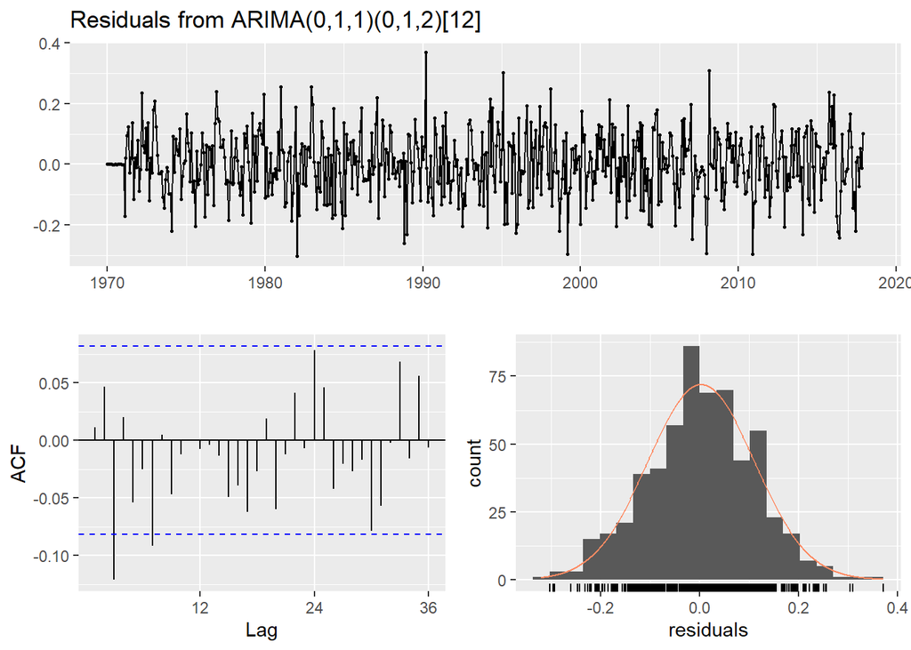

```
##
##  Ljung-Box test
##
## data:  Residuals from ARIMA(0,1,1)(0,1,2)[12]
## Q* = 30.932, df = 21, p-value = 0.07479
##
## Model df: 3.   Total lags used: 24
```

```r
checkresiduals(ari)
```

Here the visual forecast in Train and Test.

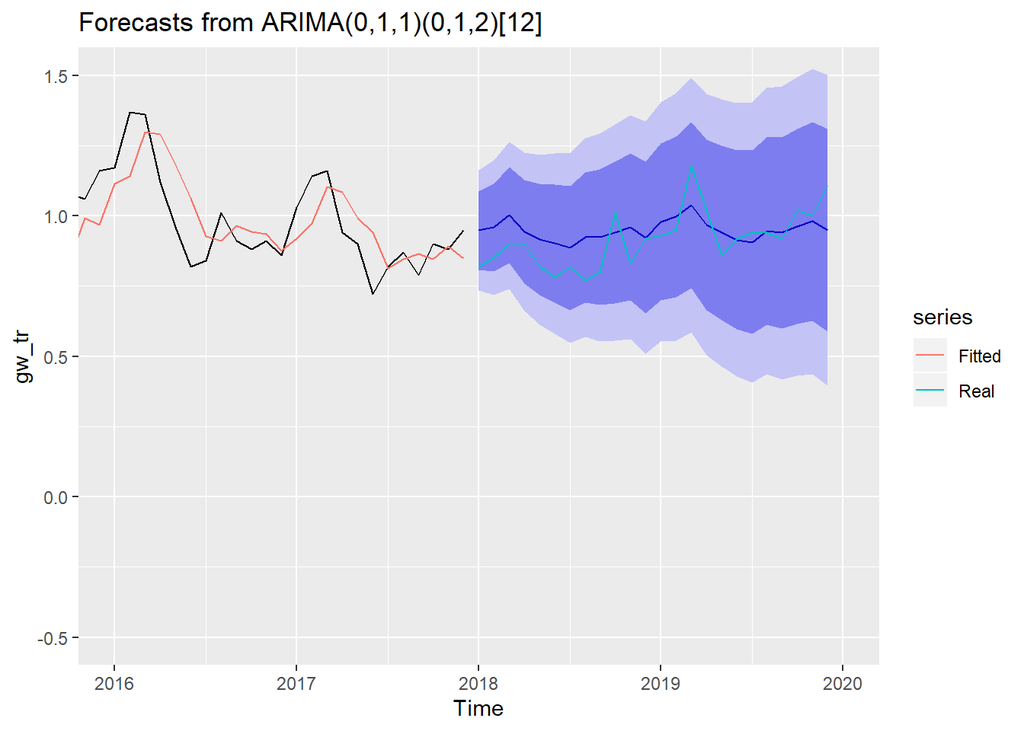

```r
autoplot(ari_fcst) +
  autolayer(gw_tst, series = "Real") + autolayer(ari$fitted, series="Fitted") + coord_cartesian(ylim=c(-0.5,1.5), xlim = c(2016,2020))
```

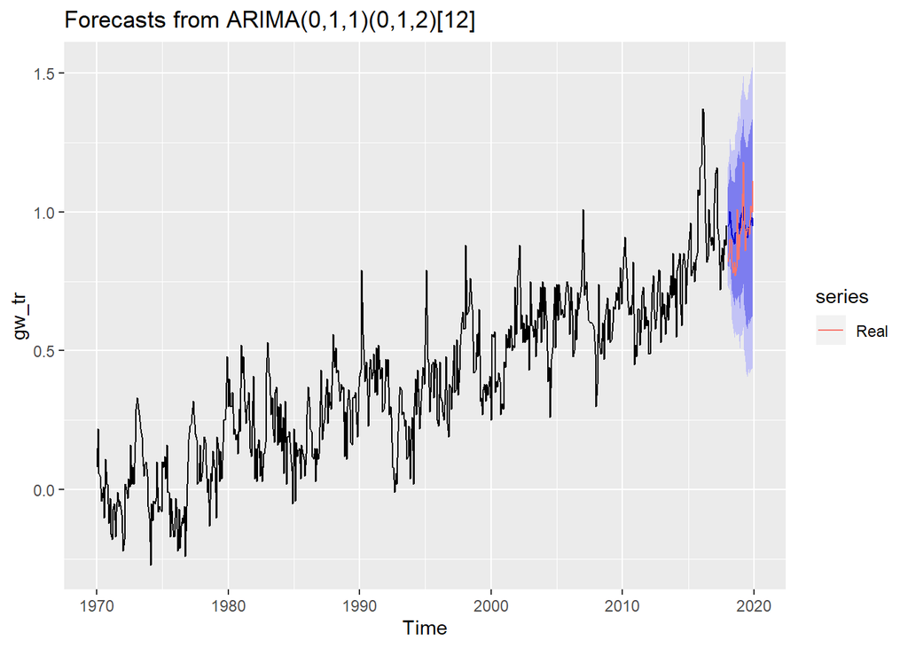

```r
autoplot(ari_fcst) +
  autolayer(gw_tst, series = "Real")
```

# 6. Neural Network

$$NNAR(p,P,k)s$$

- Where p is the number of lags that the network will take as inputs. For instance NNAR(5,0,0) would take the last five $x_t$ as inputs for the forecast.
- P is the last xt from the same season.
- k represents the number of neurons in the hidden layer.
- s represents seasonality.

The nnetar function set this p,P,k, but unless k must be optimized with the parameter lambda. As well the repeats parameter that assign the random weights for the neurons.

- 15 lags as input.

```r
library(astsa)
set.seed(123)
nn <- nnetar(gw_tr, 15,1,8, lambda = 2, repeats = 3)
accuracy(forecast(nn,h=24), gw_tst)
```

```
##                       ME       RMSE        MAE       MPE     MAPE
## Training set -0.01374694 0.09408297 0.06834815      -Inf      Inf
## Test set     -0.01702016 0.12226773 0.09612597 -2.762478 10.57583
##                   MASE        ACF1 Theil's U
## Training set 0.4445152 -0.03060489        NA
## Test set     0.6251735  0.34253878  1.226572
```

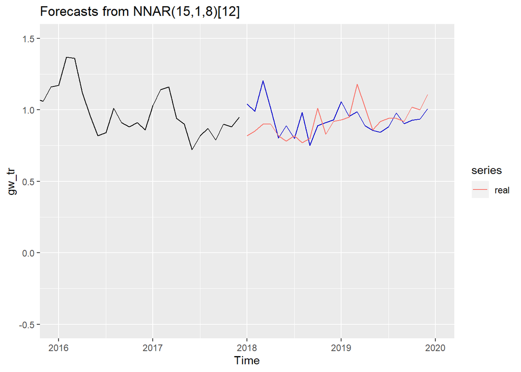

```r
autoplot(forecast(nn,h=24)) + autolayer(gw_tst, series="real") +  coord_cartesian(ylim=c(-0.5,1.5), xlim = c(2016,2020))
```

This is the function I created to optimize lambda and repeats.

```r
nnar <- function(train, test, h, repeats) {
  set.lambda <- seq(1,10, by=.1)
  set.repeats <- seq(1, repeats, by=1)
  rmse = c()
  rmse.r = c()

set.seed(123)
  for(i in 1:length(set.lambda)) {
  set.seed(123)
  x <- nnetar(train, lambda = set.lambda[i], repeats = repeats)
  ac <- accuracy(forecast(x,h=h), test)
  rmse = c(rmse, ac[2,2])
  }

ggrmse <- data.frame(Number = set.lambda,
                     RMSE = rmse)
a = ggplot(ggrmse, aes(Number, RMSE)) +
  geom_line(color="blue", size=1)


lambda.opt = set.lambda[which.min(rmse)]

set.seed(123)
  for(i in 1:length(set.repeats)) {
    set.seed(123)
    x <- nnetar(train, lambda = lambda.opt, repeats = set.repeats[i])
    ac <- accuracy(forecast(x,h=24), test)
    rmse.r = c(rmse.r, ac[2,2])
  }
ggrmse.r <- data.frame(Number = set.repeats,
                   RMSE = rmse.r
                   )

b = ggplot(ggrmse.r, aes(Number, RMSE)) +
  geom_line(color = "blue", size=1)


re.opt = set.repeats[which.min(rmse.r)]

list(a,b,lambda.opt,re.opt)

}
```

```r
# nnar(gw_tr, gw_tst, 24, 30)
```

# Predictions.

Now that all models have been trained it’s time to forecast the next year!

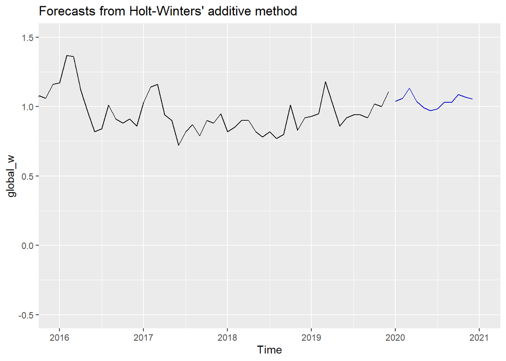

```r
autoplot(hw(global_w, h=12),PI = F) + coord_cartesian(ylim=c(-0.5,1.5), xlim = c(2016,2021))
```

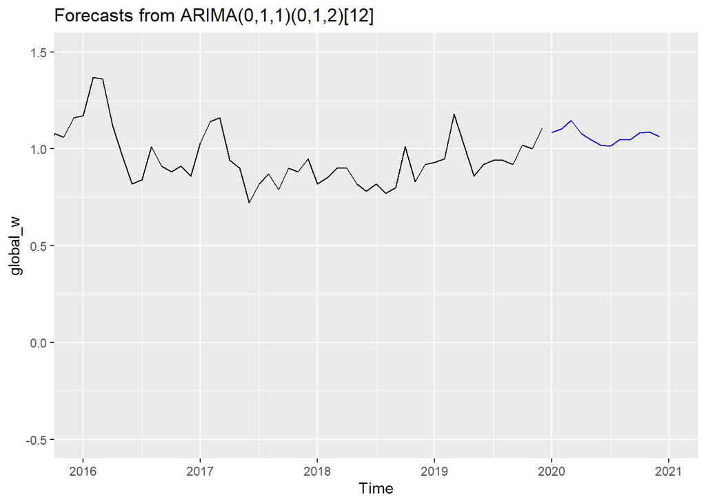

```r
ari <- Arima(global_w, order = c(0,1,1), seasonal = c(0,1,2))
autoplot(forecast(ari, h=12), PI=F)+ coord_cartesian(ylim=c(-0.5,1.5), xlim = c(2016,2021))
```

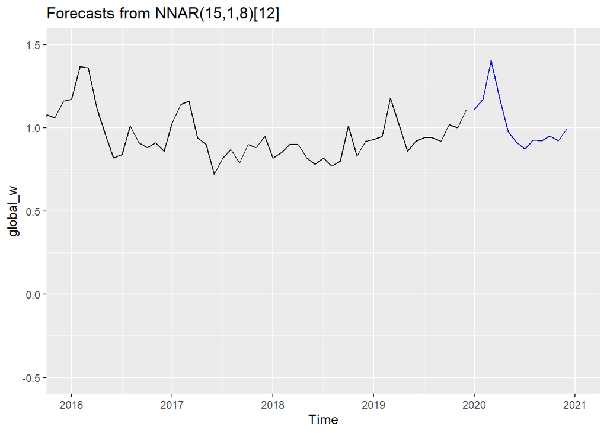

```r
set.seed(123)
nn <- nnetar(global_w, 15,1,8,lambda = 2, repeats = 3)
autoplot(forecast(nn, h=12))+ coord_cartesian(ylim=c(-0.5,1.5), xlim = c(2016,2021))
```